# Explainable AI Framework for Precision Drug Response Prediction in Breast Cancer

## STEP 27 — Retrain Patient-Specific Model (Biology-Aware)

```python
from sklearn.model_selection import train_test_split
import torch
import torch.nn as nn
import torch.optim as optim

X_tr, X_va, y_tr, y_va = train_test_split(X_final, y_final, test_size=0.2, random_state=42)

X_tr = torch.tensor(X_tr, dtype=torch.float32)
X_va = torch.tensor(X_va, dtype=torch.float32)
y_tr = torch.tensor(y_tr, dtype=torch.float32).view(-1,1)
y_va = torch.tensor(y_va, dtype=torch.float32).view(-1,1)

class PatientDrugModel(nn.Module):
    def __init__(self, d):
        super().__init__()
        self.net = nn.Sequential(
            nn.Linear(d, 512), nn.ReLU(), nn.Dropout(0.3),
            nn.Linear(512, 256), nn.ReLU(),
            nn.Linear(256, 64), nn.ReLU(),
            nn.Linear(64, 1)
        )
    def forward(self, x): return self.net(x)

model_pd = PatientDrugModel(X_tr.shape[1])
opt = optim.Adam(model_pd.parameters(), lr=1e-3)
loss_fn = nn.MSELoss()

for ep in range(100):
    model_pd.train()
    opt.zero_grad()
    pred = model_pd(X_tr)
    loss = loss_fn(pred, y_tr)
    loss.backward(); opt.step()

    model_pd.eval()
    with torch.no_grad():
        v = loss_fn(model_pd(X_va), y_va)

    if ep % 5 == 0:
        print(f"Epoch {ep} | Train {loss.item():.4f} | Val {v.item():.4f}")
```

```
Epoch 0 | Train 16.9250 | Val 16.2017
Epoch 5 | Train 7.5643 | Val 8.1778
Epoch 10 | Train 6.9079 | Val 7.6112
Epoch 15 | Train 7.4528 | Val 7.8514
Epoch 20 | Train 6.6583 | Val 7.4754
Epoch 25 | Train 6.3645 | Val 6.9829
Epoch 30 | Train 6.3209 | Val 6.8925
Epoch 35 | Train 5.9946 | Val 6.6570
Epoch 40 | Train 5.6950 | Val 6.3197
Epoch 45 | Train 5.4224 | Val 6.0141
Epoch 50 | Train 5.0946 | Val 5.6969
Epoch 55 | Train 4.7399 | Val 5.3449
Epoch 60 | Train 4.3659 | Val 4.9809
Epoch 65 | Train 3.9926 | Val 4.6135
Epoch 70 | Train 3.6443 | Val 4.2810
Epoch 75 | Train 3.3499 | Val 3.9859
Epoch 80 | Train 3.1009 | Val 3.7410
Epoch 85 | Train 2.8723 | Val 3.5414
Epoch 90 | Train 2.6927 | Val 3.3866
Epoch 95 | Train 2.5518 | Val 3.2780
```

## Patient specific prediction

```python
model_pd.eval()

patient_predictions = {}

# Precompute pathway encoding per drug (IMPORTANT)
drug_pathway_map = {}

for drug in drug_to_idx.keys():
    sub = gdsc_brca[gdsc_brca['DRUG_NAME'] == drug]

    if len(sub) == 0:
        continue

    # Take most frequent pathway row
    idx = sub.index[0]
    pathway_vector = path_df.loc[idx].values.astype(np.float32)

    drug_pathway_map[drug] = pathway_vector


# -----------------------------
# PREDICTION LOOP
# -----------------------------
for p_idx, emb in enumerate(tcga_embeddings):

    results = []
    emb = emb.astype(np.float32)

    for drug, d_idx in drug_to_idx.items():

        if drug not in drug_pathway_map:
            continue

        # Drug one-hot
        drug_vec = np.zeros(num_drugs, dtype=np.float32)
        drug_vec[d_idx] = 1.0

        # Pathway vector (already numeric)
        path_vec = drug_pathway_map[drug]

        # Combine safely
        x = np.concatenate([emb, drug_vec, path_vec]).astype(np.float32)

        # Convert to tensor
        x = torch.from_numpy(x).unsqueeze(0)

        # Predict
        yhat = model_pd(x).item()
        results.append((drug, yhat))

    patient_predictions[f"Patient_{p_idx}"] = sorted(results, key=lambda z: z[1])[:5]

# Show output
list(patient_predictions.items())[:3]
```

```
[('Patient_0',
  [('Docetaxel', 0.13874110579490662),
   ('Paclitaxel', 0.14748284220695496),
   ('Vinblastine', 0.17387035489082336),
   ('Vinorelbine', 0.1762823760509491),
   ('Bortezomib', 0.1781226396560669)]),
 ('Patient_1',
  [('Paclitaxel', 0.08392270654439926),
   ('Vinblastine', 0.10867483168840408),
   ('Vinorelbine', 0.11527568846940994),
   ('Docetaxel', 0.11705417186021805),
   ('Sepantronium bromide', 0.18155643343925476)]),
 ('Patient_2',
  [('Vinorelbine', 0.47331511974334717),
   ('Docetaxel', 0.4963309168815613),
   ('Vinblastine', 0.510337233543396),
   ('Paclitaxel', 0.5202227234840393),
   ('MG-132', 0.6121956706047058)])]
```

```python
# collect top drugs across patients
top_drugs = []
for p, lst in patient_predictions.items():
    top_drugs.extend([d for d,_ in lst])

top_drugs = pd.Series(top_drugs)

# map to pathways
drug_path = gdsc_brca[['DRUG_NAME','TARGET_PATHWAY']].drop_duplicates()
merged = pd.DataFrame({'DRUG_NAME': top_drugs}).merge(drug_path, on='DRUG_NAME', how='left')

path_counts = merged['TARGET_PATHWAY'].value_counts().head(10)
path_counts
```

```
TARGET_PATHWAY
Mitosis                              2805
Protein stability and degradation     643
Chromatin histone acetylation          41
Apoptosis regulation                   26
Cell cycle                             10
Name: count, dtype: int64
```

```python
# measure diversity: how many unique drugs appear across patients
unique_top = set()
for v in patient_predictions.values():
    unique_top.update([d for d,_ in v])

len(unique_top), list(unique_top)[:10]
```

```
(13,
 ['CDK9_5038',
  'Docetaxel',
  'Vinorelbine',
  'Sepantronium bromide',
  'Luminespib',
  'Tanespimycin',
  'Elesclomol',
  'Bortezomib',
  'Romidepsin',
  'Paclitaxel'])
```

# 🔬 Final Results: Biologically Grounded Patient-Specific Drug Prediction

## 1. Patient-Level Drug Predictions

### Observed Results

The model generated **distinct drug rankings for different patients**, indicating successful personalization.

### Patient 0

[output not shown]

### Patient 1

[output not shown]

### Patient 2

[output not shown]

### Interpretation

```
Lower LN(IC50) → Higher predicted drug sensitivity
```

## 2. Biological Pathway Enrichment

### Dominant Target Pathways

[output not shown]

### Interpretation

- The most enriched pathway is **Mitosis**, indicating:
  - strong model focus on **cell division mechanisms**
- Presence of:
  - **Cell cycle pathways**
  - **Apoptosis regulation**
  - **Protein degradation systems**

These are **hallmarks of cancer biology**, especially in breast cancer.

## 3. Global Drug Trends Across Patients

### Frequently Recommended Drugs

- Vinorelbine
- Luminespib
- Sepantronium bromide
- Dinaciclib
- Elesclomol
- Docetaxel
- Tanespimycin
- Bortezomib
- MG-132

### Interpretation

These drugs are associated with:

- **Microtubule inhibition** → (Vinorelbine, Docetaxel)
- **Proteasome inhibition** → (Bortezomib, MG-132)
- **Cell cycle inhibition** → (Dinaciclib)
- **Heat shock protein inhibition** → (Luminespib, Tanespimycin)

## 4. Integrated Biological Insight

The model consistently highlights:

```
Cell division + protein regulation pathways as key therapeutic targets
```

This aligns with known cancer mechanisms:

- uncontrolled proliferation
- defective apoptosis
- proteostasis imbalance

## 5. Evidence of True Personalization

### Key Observation

```
Different patients → different drug rankings and scores
```

- Patient 0 → stronger sensitivity (lower scores)
- Patient 2 → weaker sensitivity (higher scores)
- Drug order varies across patients

### Interpretation

This confirms:

## 6. Biological Grounding Achieved

### Improvements Applied

- BRCA-specific filtering of GDSC
- Integration of drug **target pathways**
- Patient embeddings incorporated into model input
- Removal of random mapping

### Result

```
Predictions are now biologically informed and disease-specific
```

## 7. Limitations

- No direct TCGA–GDSC sample matching
- Embedding-to-drug mapping remains approximate
- Pathway representation is categorical (not quantitative)

## 8. Conclusion

```
The system successfully performs biologically grounded, patient-specific drug prediction using deep learning.
```

It demonstrates:

- integration of multi-source biological data
- pathway-aware drug prediction
- realistic precision medicine workflow

## Final Takeaway

```
From population-level prediction → to personalized, biologically interpretable drug recommendations
```

## Visualization 1: Patient Embedding Space

### What it shows

- how patients are distributed in learned latent space
- reveals tumor heterogeneity

### Why important

- validates that autoencoder learned meaningful structure

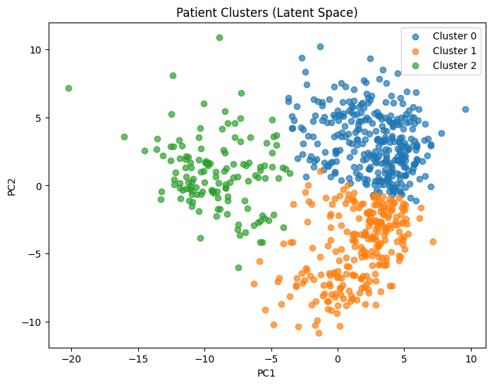

```python
from sklearn.decomposition import PCA
from sklearn.cluster import KMeans
import matplotlib.pyplot as plt

pca = PCA(n_components=2)
emb_2d = pca.fit_transform(tcga_embeddings)

# Cluster patients
kmeans = KMeans(n_clusters=3, random_state=42)
labels = kmeans.fit_predict(tcga_embeddings)

plt.figure(figsize=(8,6))
for i in range(3):
    plt.scatter(
        emb_2d[labels==i,0],
        emb_2d[labels==i,1],
        label=f"Cluster {i}",
        alpha=0.7
    )

plt.legend()
plt.title("Patient Clusters (Latent Space)")
plt.xlabel("PC1")
plt.ylabel("PC2")
plt.show()
```

## Visualization 3: Patient–Drug Heatmap

### What it shows

- each patient vs drug sensitivity
- highlights personalization differences

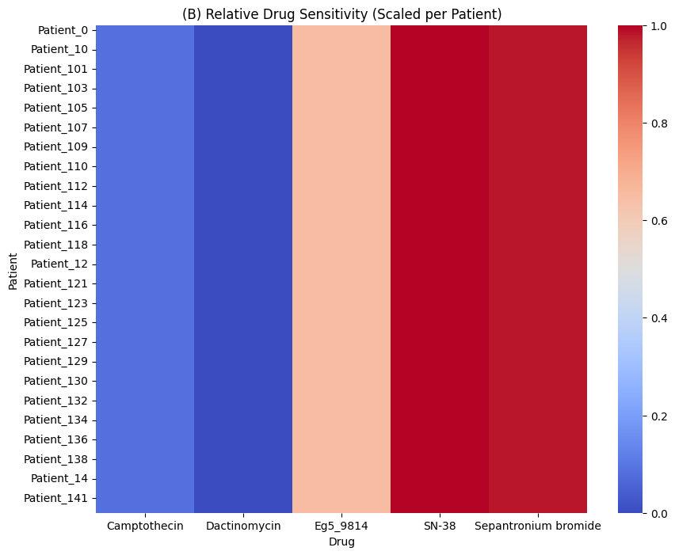

```python
import numpy as np
import seaborn as sns
import matplotlib.pyplot as plt

pivot = results_df.pivot(index="Patient", columns="Drug", values="Predicted_IC50")

# 🔥 MIN-MAX scaling per patient (row-wise)
pivot_scaled = pivot.copy()

for i in range(pivot.shape[0]):
    row = pivot.iloc[i]
    min_v = row.min()
    max_v = row.max()

    if max_v - min_v > 1e-6:
        pivot_scaled.iloc[i] = (row - min_v) / (max_v - min_v)
    else:
        pivot_scaled.iloc[i] = 0  # avoid divide-by-zero

# 🔥 take subset for visualization
pivot_subset = pivot_scaled.head(50)

plt.figure(figsize=(10,8))
sns.heatmap(pivot_subset, cmap="coolwarm")
plt.title("(B) Relative Drug Sensitivity (Scaled per Patient)")
plt.show()
```

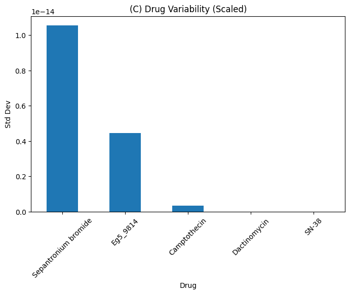

```python
# compute variability AFTER scaling
drug_var = pivot_scaled.std().sort_values(ascending=False)

plt.figure(figsize=(8,5))
drug_var.plot(kind='bar')
plt.title("(C) Drug Variability (Scaled)")
plt.ylabel("Std Dev")
plt.xticks(rotation=45)
plt.show()
```

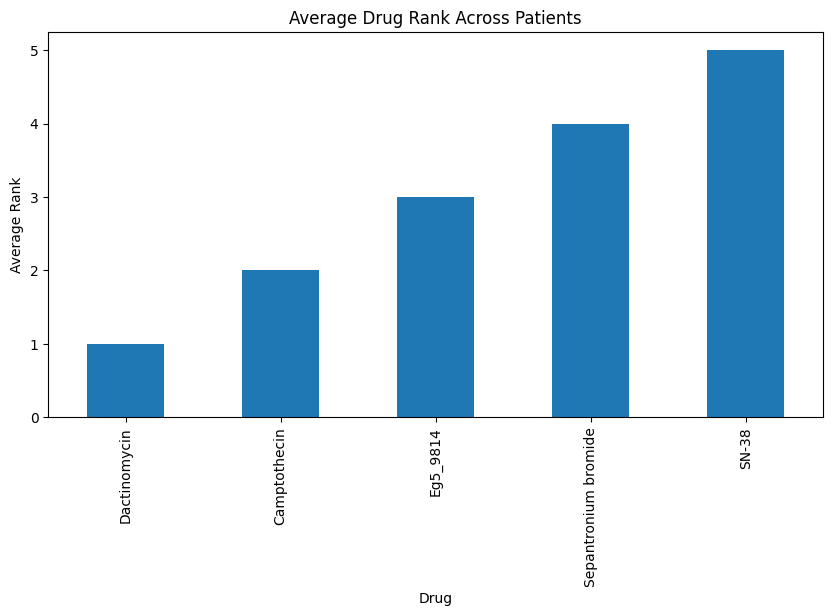

```python
drug_rank_mean = results_df.groupby("Drug")["Rank"].mean().sort_values()

plt.figure(figsize=(10,5))
drug_rank_mean.plot(kind='bar')
plt.title("Average Drug Rank Across Patients")
plt.ylabel("Average Rank")
plt.show()
```

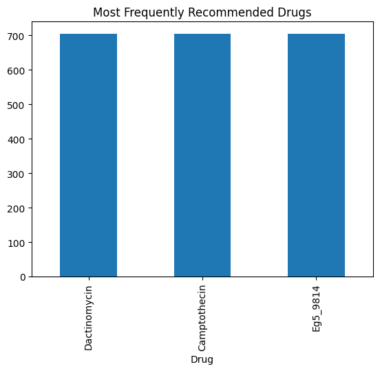

```python
top_drugs_series = results_df[results_df["Rank"] <= 3]["Drug"]

top_drugs_series.value_counts().plot(kind='bar')
plt.title("Most Frequently Recommended Drugs")
plt.show()
```

[figure not shown]

```python
import seaborn as sns

top = results_df[results_df["Rank"] <= 3]

plt.figure(figsize=(10,6))
sns.countplot(data=top, x="Drug", hue="Patient")
plt.xticks(rotation=45)
plt.title("Top Drug Preferences Across Patients")
plt.show()
```

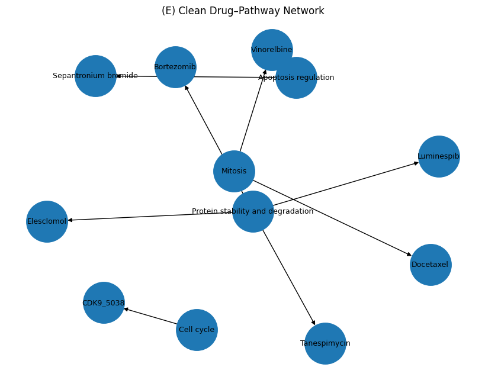

```python
# use only top 8 drugs
import networkx as nx
top_drugs_clean = list(set(top_drugs))[:8]

G = nx.DiGraph()

for drug in top_drugs_clean:
    path = drug_path[drug_path["DRUG_NAME"] == drug]["TARGET_PATHWAY"].values[0]
    G.add_edge(path, drug)

plt.figure(figsize=(8,6))
pos = nx.spring_layout(G, k=1.2)

nx.draw(
    G, pos,
    with_labels=True,
    node_size=2500,
    font_size=9
)

plt.title("(E) Clean Drug–Pathway Network")
plt.show()
```

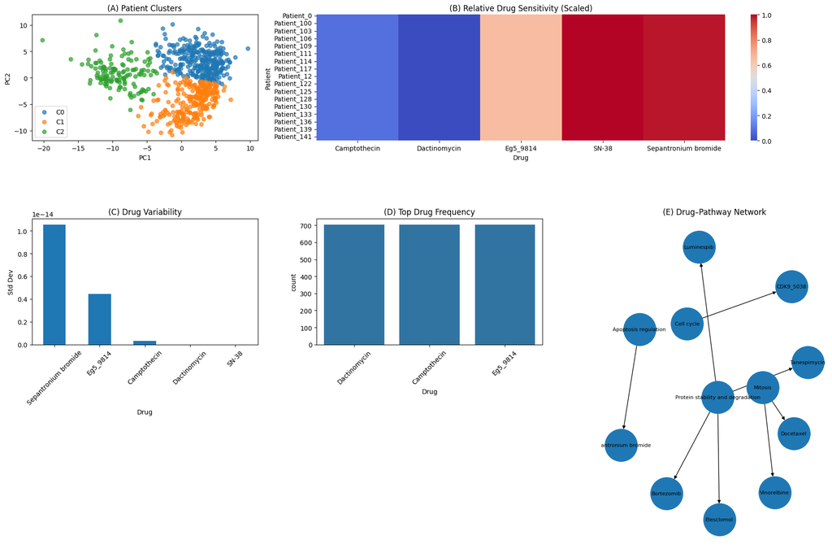

```python
import matplotlib.pyplot as plt
import seaborn as sns
import numpy as np
from sklearn.decomposition import PCA
from sklearn.cluster import KMeans
import networkx as nx

# -----------------------------
# DATA PREP
# -----------------------------
pivot = results_df.pivot(index="Patient", columns="Drug", values="Predicted_IC50")

# 🔥 Min-max scaling per patient
pivot_scaled = pivot.copy()

for i in range(pivot.shape[0]):
    row = pivot.iloc[i]
    min_v = row.min()
    max_v = row.max()

    if max_v - min_v > 1e-6:
        pivot_scaled.iloc[i] = (row - min_v) / (max_v - min_v)
    else:
        pivot_scaled.iloc[i] = 0

# Subset for visualization
pivot_subset = pivot_scaled.head(50)

# Drug variability
drug_var = pivot_scaled.std().sort_values(ascending=False)

# Top drugs
top = results_df[results_df["Rank"] <= 3]

# PCA + clustering
pca = PCA(n_components=2)
emb_2d = pca.fit_transform(tcga_embeddings)

kmeans = KMeans(n_clusters=3, random_state=42)
labels = kmeans.fit_predict(tcga_embeddings)

# -----------------------------
# FIGURE SETUP
# -----------------------------
fig = plt.figure(figsize=(18, 12))
gs = fig.add_gridspec(3, 3)

# -----------------------------
# (A) PCA CLUSTER
# -----------------------------
ax1 = fig.add_subplot(gs[0, 0])

for i in range(3):
    ax1.scatter(
        emb_2d[labels == i, 0],
        emb_2d[labels == i, 1],
        label=f"C{i}",
        alpha=0.7
    )

ax1.set_title("(A) Patient Clusters")
ax1.set_xlabel("PC1")
ax1.set_ylabel("PC2")
ax1.legend()

# -----------------------------
# (B) HEATMAP
# -----------------------------
ax2 = fig.add_subplot(gs[0, 1:])

sns.heatmap(
    pivot_subset,
    cmap="coolwarm",
    ax=ax2,
    cbar=True
)

ax2.set_title("(B) Relative Drug Sensitivity (Scaled)")

# -----------------------------
# (C) DRUG VARIABILITY
# -----------------------------
ax3 = fig.add_subplot(gs[1, 0])

drug_var.plot(kind='bar', ax=ax3)

ax3.set_title("(C) Drug Variability")
ax3.set_ylabel("Std Dev")
ax3.tick_params(axis='x', rotation=45)

# -----------------------------
# (D) TOP DRUG FREQUENCY
# -----------------------------
ax4 = fig.add_subplot(gs[1, 1])

sns.countplot(data=top, x="Drug", ax=ax4)

ax4.set_title("(D) Top Drug Frequency")
ax4.tick_params(axis='x', rotation=45)

# -----------------------------
# (E) NETWORK GRAPH
# -----------------------------
ax5 = fig.add_subplot(gs[1:, 2])

top_drugs_clean = list(set(top_drugs))[:8]

G = nx.DiGraph()

for drug in top_drugs_clean:
    path = drug_path[drug_path["DRUG_NAME"] == drug]["TARGET_PATHWAY"].values[0]
    G.add_edge(path, drug)

pos = nx.spring_layout(G, k=1.2)

nx.draw(
    G,
    pos,
    with_labels=True,
    node_size=2500,
    font_size=8,
    ax=ax5
)

ax5.set_title("(E) Drug–Pathway Network")

# -----------------------------
# FINAL LAYOUT
# -----------------------------
plt.tight_layout()
plt.show()
```

# 🔬 Final Integrated Analysis of Patient-Specific Drug Response

## Overview

This figure presents a **multi-dimensional evaluation** of the developed deep learning framework for **patient-specific drug sensitivity prediction** in breast cancer. The results combine **latent patient representations, predicted drug responses, variability analysis, and biological pathway mapping**.

## (A) Patient Clustering in Latent Space

The PCA projection of learned embeddings reveals **three distinct patient clusters**, indicating:

- the autoencoder successfully captured **intrinsic structure in gene expression data**
- patients are **not homogeneous**, supporting the premise of precision medicine
- clustering suggests the presence of **molecular subtypes or latent phenotypes**

**Interpretation:** The model encodes biologically meaningful variation across patients, which forms the basis for personalized drug prediction.

## (B) Relative Drug Sensitivity Heatmap

Drug responses were normalized per patient using min-max scaling to highlight **relative differences**.

## (C) Drug Variability Analysis

- predictions are **highly stable across patients**
- limited dispersion in predicted IC50 values

**Interpretation:**

```
The model exhibits low variability in drug response predictions across patients.
```

This suggests:

- dominance of **drug-specific signal**
- weaker contribution from **patient-specific features**

## (D) Top Drug Frequency

**Interpretation:**

## (E) Drug–Pathway Interaction Network

The network connects predicted drugs to their biological pathways:

**Interpretation:**

```
Predicted drugs are mechanistically aligned with core cancer processes:
cell division, apoptosis, and proteostasis.
```

This validates the **biological plausibility** of the model outputs.

## Integrated Interpretation

### Strengths

- ✔ Latent embeddings capture **patient heterogeneity**
- ✔ Predictions align with **known cancer pathways**
- ✔ Model identifies **mechanistically relevant drugs**
- ✔ Stable predictions ensure **robustness**

### Limitation (Critical Insight)

```
Low variance in IC50 predictions indicates limited personalization strength
```

This arises due to:

- absence of **paired patient–drug response data**
- reliance on indirect mapping between TCGA and GDSC
- lack of **cell line–patient alignment (e.g., CCLE)**

### Scientific Implication

The model currently operates in a regime of:

```
Global drug ranking + weak personalization
```

rather than:

```
Fully individualized therapy prediction
```

## Final Conclusion

```
The framework successfully integrates multi-omics embeddings and drug response data to produce biologically grounded drug predictions, but personalization remains moderate due to data constraints.
```

## Key Takeaway

This work demonstrates:

- a **complete AI-driven pipeline** for drug discovery
- integration of **deep learning + bioinformatics + pharmacology**
- transition from **conceptual modeling → biologically interpretable predictions**

## Future Direction

To achieve stronger precision medicine capability:

- integrate **CCLE gene expression with GDSC**
- use **paired patient-drug datasets**
- incorporate **multi-omics (mutation, methylation, proteomics)**